# DEF-D Fysieke Ontwerpopdracht 2 invul template

## Groep informatie

Aan het einde van deze ontwerpopdracht lever je als groep één gezamenlijk notebook in (als in *PR* op GitHub en de link op Brightspace). Zet jullie groepsnummer, studienummers en namen in onderstaande tabel zodat wij zeker weten dat het groepsvormen goed is gegaan.

[output not shown]

## *Opdracht 1*: Sanity check 3

#### Voeg hier een foto van de schets van je plaatcondensator in. Geef daarbij ook duidelijk de waarde van $A$ en $d$ aan.

[figure not shown]

```python
# Schrijf hier een python functie die de capaciteit van een plaatcondensator uitrekent. Zorg dat de functie
# als input de ontwerpparameters van de vlakke plaat formule accepteert (oppervlakte, afstand en diëlektrische
# constante) en als output de capaciteit van de vlakke plaat condensator met die ontwerpparameters.
# Je gaat deze formule de rest van de dag gebruiken: controleer hem goed!

def vlakkeplaat(A, epsilon_r, d):
    C = 8.854e-12 * epsilon_r * A / d * 1e12
    return C
# Optioneel: schrijf je functie zodanig dat je arrays als input kan geven en (dus) ook arrays als output.
```

```python
# Gebruik je formule om uit te rekenen wat je verwacht dat de capaciteit van jullie vlakke plaat condensatoren
# gaat zijn.

C = [vlakkeplaat(0.01, 2.6, 0.0001)]


print(f"Berekende capaciteit plaatcondensator groep 58 is {C[0]:.1f} pF")
```

```
Berekende capaciteit plaatcondensator groep 58 is 2302.0 pF
```

#### Voeg hier een foto van je plaatcondensator en van de meting op de scope in. Dus 2 foto's.

[figure not shown]

De scope wijkt dusdanig af van de theorie omdat de condensator erg onnauwkeurig is. Zo is het oppervlakte, hoewel nauwkeurig opgemeten, veranderd door vervorming en bevat het meerdere prikgaten. Bovendien is de afstand en het contact tussen de verschillende lagen vele malen groter dan de papierdikte omdat ze zich slecht laten samendrukken in de opstelling.

### Meting capaciteit

Vul onderstaande tabel in. Bij Sanity check 2 heb je afgeleid hoe je van berekende capaciteit naar berekend voltage gaat en terug.

[output not shown]

## *Opdracht 2:* Synthese.

#### Voeg hier voor een foto van je schets(en) van minimaal drie sensoren in.

[figure not shown]

## Opdracht 3: Welke sensor gaan jullie maken?

Inhaal alleen, niet van toepassing

## Opdracht 4: Uitgewerkte schets (afmetingen!) en plot van de ontwerpgrafiek.

#### Voeg hier een foto van jullie uitgewerkte schets van de sensor die jullie gaan maken in

[figure not shown]

De dikte van de metalenplaat en van het karton is 1mm. Bovenop het karton en de metalen plaat zit papier getapet (0.1mm) om de permittiviteit tussen de platen te bevorderen. Bovendien zorgt de papierenlaag ervoor dat de verhoogde metalen plaat gemakkelijk kan schuiven

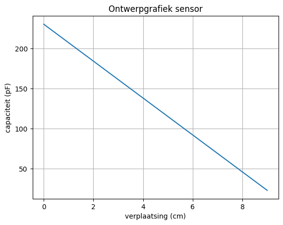

```python
# Plot hier de verwachte ontwerpgrafiek van jullie sensoren.
import numpy as np
import matplotlib.pyplot as plt

er_papier = 2.6    # relatieve permittiviteit karton
d = 0.001          # dikte papier
breedte = 0.10     # breedte metalen plaat

x = np.linspace(0, 0.09, 100)      # verplaatsing van 0 tot 9cm
A = breedte * (0.10 - x)           # overlap neemt af van 10 cm tot 1 cm

C = [vlakkeplaat(a, er_papier, d) for a in A]

plt.plot(x * 100, C)
plt.plot()
plt.xlabel("verplaatsing (cm)")
plt.ylabel("capaciteit (pF)")
plt.title("Ontwerpgrafiek sensor")
plt.grid()
plt.show()
```

## Opdracht 5: Invullen tabel LTSpice.

|  | Capaciteit waarde (pF) | LTSpice berekend output Vpp (mV) |
| --- | --- | --- |
| minmale capaciteit | 14 | 140 |
| gemiddelde capaciteit | 103 | 1040 |
| maximale capaciteit | 220 | 2300 |

## Opdracht 6: Foto's werkende opstelling.

#### Voeg hier de foto's van je sensoren in actie in.

[figure not shown]

## Opdracht 7: Plot de kalibratiegrafiek.

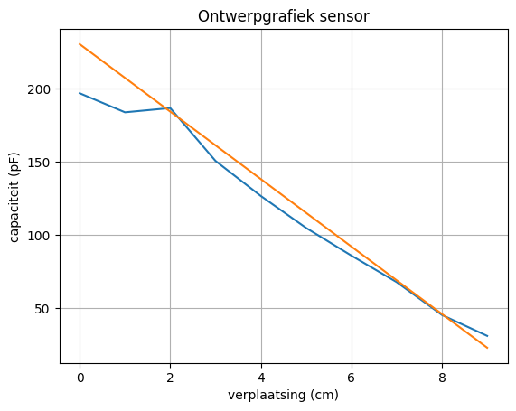

```python
# Plot hier je gemeten kalibratiegrafiek en plot in dezelfde figuur ook je verwachte ontwerpgrafiek.
verplaatsing = [0,1,2,3,4,5,6,7,8,9]
capaciteit = [196.7,183.7,186.6,150.5,126.6,104.8,85.9,67.8,45.4,31.1]
plt.plot(verplaatsing,capaciteit)
plt.plot(x * 100, C)
plt.plot()
plt.xlabel("verplaatsing (cm)")
plt.ylabel("capaciteit (pF)")
plt.title("Ontwerpgrafiek sensor")
plt.grid()
plt.show()
```

## Opdracht 9: Uiteindelijke ontwerp en kalibratiegrafiek.

#### Voeg hier een foto van je uiteindelijke sensor in.

[figure not shown]

```python
# Plot hier je oorspronkelijke en je uiteindelijke kalibratiegrafieken, fit daar een bijpassende lijn door
# en zet ook de verwachte ontwerpgrafiek erbij
```

## Opdracht 11: Kopieer hieronder de leerdoelen.

1. Het kunnen gebruiken van de eigenschappen van een elektrische component in een ontwerpproces om een fysische grootheid te meten.
2. Kennis hebben van gedrag van elektrische componenten en meetopstellingen.
3. Onderdelen van een datasheet zoals een kalibratiegrafiek opstellen, gevoeligheid en onzekerheid beschrijven.